# Workings - initial analysis before creating report

```r
library(tidyverse)
library(janitor)
library(here)
data_dictionary <- read_csv(here("data_raw/data_dictionary.csv"))
```

population estimates:

“Mid-year population estimates: Scotland and its NHS Board areas, total population by sex: 1981 to 2019”

https://www.nrscotland.gov.uk/statistics-and-data/statistics/statistics-by-theme/population/population-estimates/mid-year-population-estimates/population-estimates-time-series-data

"1) Population estimates from years 1981 to 2018 are based on the 2014 Health Board boundaries and 2019 is based on the 2019 Health Board boundaries.

"

The 2019 areas differ from the previous areas due to a boundary change at Cardowan by Stepps, between Greater Glasgow and Clyde and Lanarkshire health board areas. The boundary change resulted in approximately 400 people transferring from Greater Glasgow and Clyde to Lanarkshire. These moves have been accounted for as migration within Scotland.

```r
population_estimates <-
 read_csv(here("data_clean/population_estimates.csv"))
cancer_incidence_data <-
 read_csv(here("data_clean/cancer_incidence_data.csv"))
```

# cancer type by time

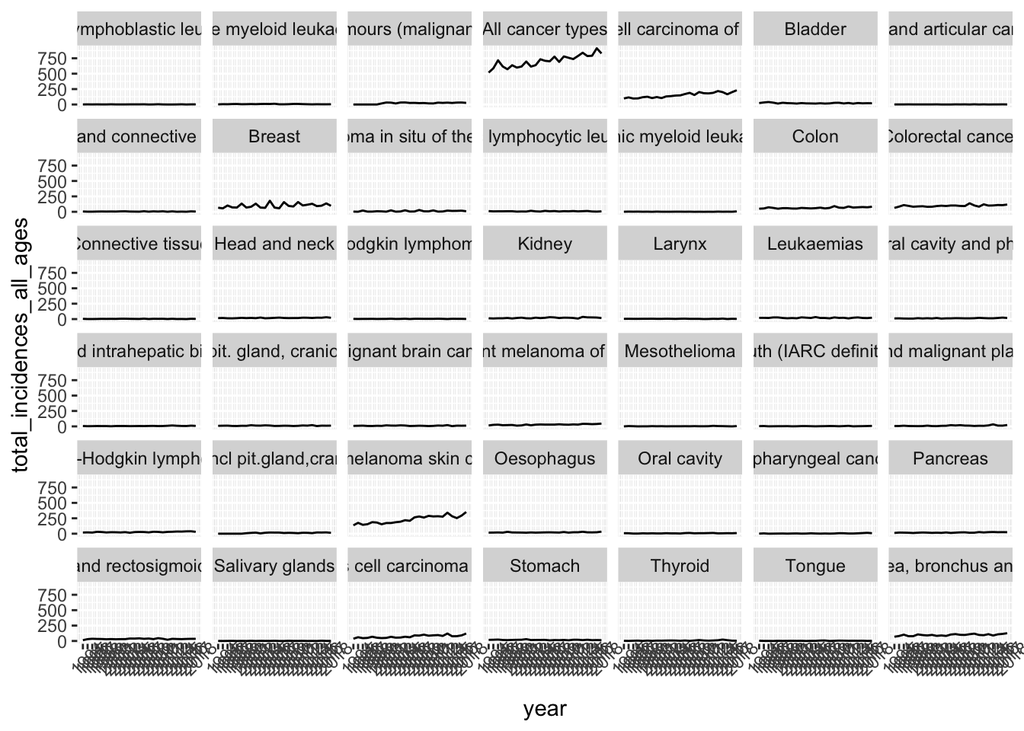

```r
cancer_incidence_data %>%
  filter(hb_name == "NHS Borders") %>%
  filter(sex == "All") %>%
  group_by(hb_name, cancer_site, year) %>%
  summarise(total_incidences_all_ages = sum(incidences_all_ages)) %>%
  ggplot() +
  aes(x = year, y = total_incidences_all_ages) +
  geom_line() +
  #theme_minimal() +
  scale_x_continuous(breaks = (min(cancer_incidence_data$year):max(cancer_incidence_data$year))) +
  scale_y_continuous(labels = scales::comma) +
  theme(axis.text.x = element_text(angle = 45)) +
  facet_wrap(~cancer_site)
```

# summary all types

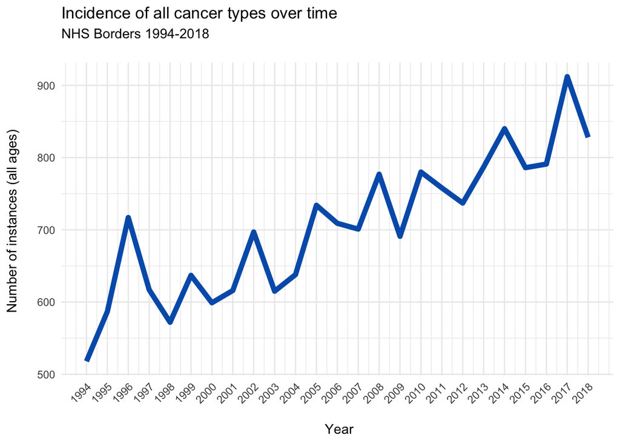

```r
cancer_incidence_data %>%
  filter(hb_name == "NHS Borders") %>%
  filter(cancer_site == "All cancer types") %>%
  filter(sex == "All") %>%
  group_by(hb_name, year) %>%
  summarise(total_incidences_all_ages = sum(incidences_all_ages)) %>%
  ggplot() +
  aes(x = year, y = total_incidences_all_ages) +
  # NHS colours: https://www.england.nhs.uk/nhsidentity/identity-guidelines/colours/
  geom_line(colour = "#005EB8", size  = 2) +
  theme_minimal() +
  scale_x_continuous(breaks = (min(cancer_incidence_data$year):max(cancer_incidence_data$year))) +
  scale_y_continuous(labels = scales::comma) +
  theme(axis.text.x = element_text(angle=45,hjust=1)) +
  labs(
    title = "Incidence of all cancer types over time",
    subtitle = "NHS Borders 1994-2018 \n",
    x = "\n Year",
    y = "Number of instances (all ages) \n"
  )
```

# Population over time

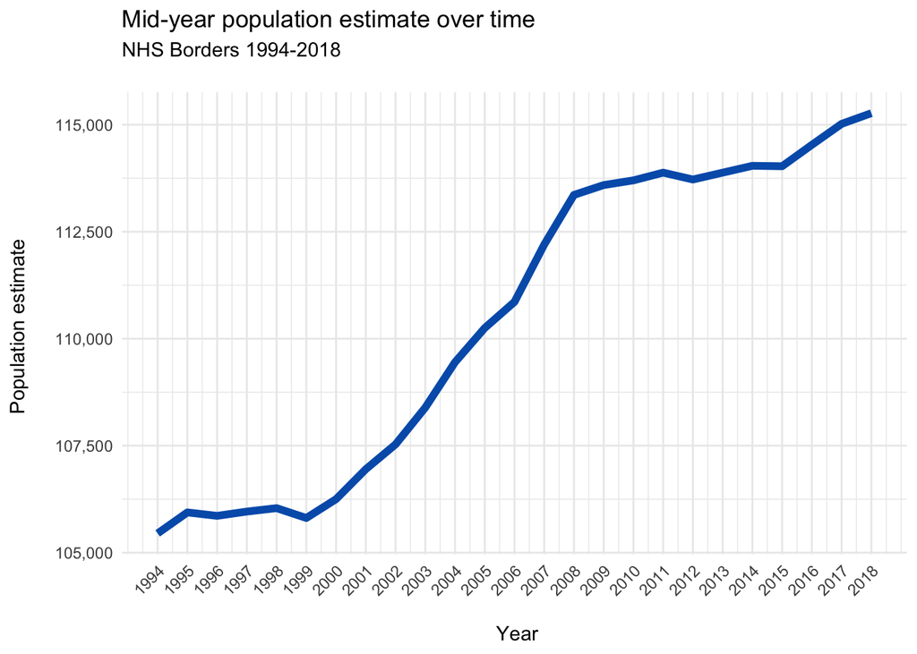

```r
population_estimates %>%
  filter(area_name == "Borders") %>%
  filter(gender == "All") %>%
  filter(year >= 1994 & year <= 2018) %>%
  group_by(area_name, year) %>%
  summarise(population_estimate = sum(population_estimate)) %>%
  ggplot() +
  aes(x = year, y = population_estimate) +
  geom_line(colour = "#005EB8", size  = 2) +
  theme_minimal() +
  scale_x_continuous(breaks = 1994:2018) +
  scale_y_continuous(labels = scales::comma) +
  theme(axis.text.x = element_text(angle=45,hjust=1)) +
    labs(
    title = "Mid-year population estimate over time",
    subtitle = "NHS Borders 1994-2018 \n",
    x = "\n Year",
    y = "Population estimate \n"
  )
```

# compare rates

The rates are calculated by applying the age-specific rates for the location being studied to a theoretical European standard population, usually expressed per 100,000 persons per year.

https://ecis.jrc.ec.europa.eu/info/glossary.html

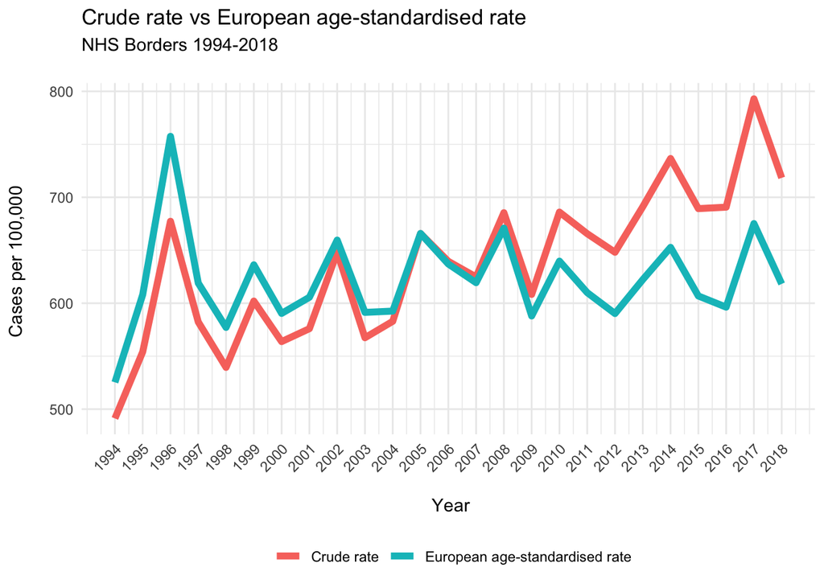

```r
# Crude rate
crude_rate <- cancer_incidence_data %>%
  filter(hb_name == "NHS Borders") %>%
  filter(cancer_site == "All cancer types") %>%
  filter(sex == "All") %>%
  mutate(measure = "Crude rate",
         rate = crude_rate) %>%
  select(hb_name, year, measure, rate)
# European age-standardised rate
european_standardised_rate <- cancer_incidence_data %>%
  filter(hb_name == "NHS Borders") %>%
  filter(cancer_site == "All cancer types") %>%
  filter(sex == "All") %>%
  mutate(measure = "European age-standardised rate",
         rate = easr) %>%
  select(hb_name, year, measure, rate)

# put these two datasets together
compare_rates <-
bind_rows(crude_rate, european_standardised_rate)

# drop intermediate tables
rm(crude_rate, european_standardised_rate)

 compare_rates %>%
  ggplot() +
  aes(x = year, y = rate, group  = measure, colour = measure  ) +
  # NHS colours: https://www.england.nhs.uk/nhsidentity/identity-guidelines/colours/
  geom_line(size  = 2) +
  theme_minimal() +
  scale_x_continuous(breaks = (min(cancer_incidence_data$year):max(cancer_incidence_data$year))) +
  scale_y_continuous(labels = scales::comma) +
  theme(axis.text.x = element_text(angle=45,hjust=1)) +
   theme(legend.position="bottom") +
     scale_fill_manual(
    values = c(
      "Crude Rate" = "#005EB8",
      "European age-standardised rate" = "#00A9CE"
     )
    ) +
  labs(
    title = "Crude rate vs European age-standardised rate",
    subtitle = "NHS Borders 1994-2018 \n",
    x = "\n Year",
    y = "Cases per 100,000 \n",
    colour = ""
  )
```

# summary type all years

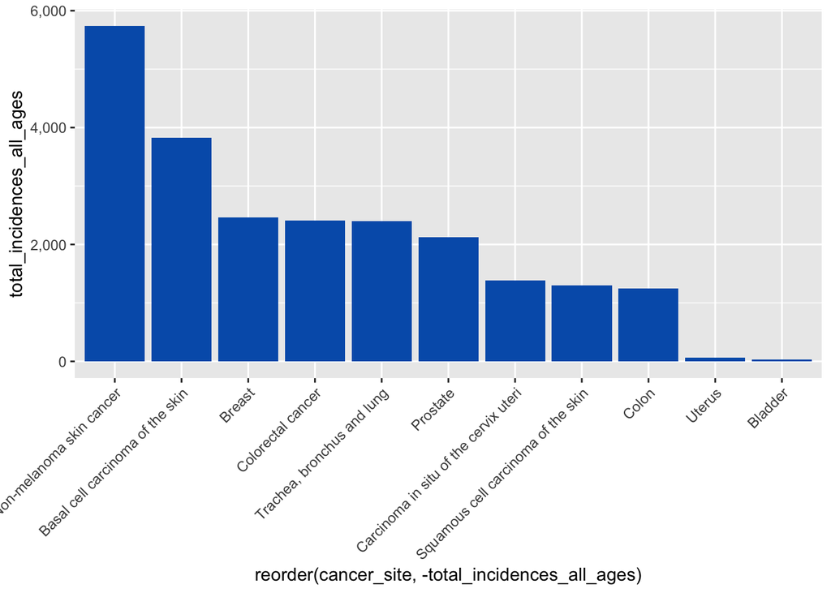

```r
cancer_incidence_data %>%
  filter(hb_name == "NHS Borders") %>%
  filter(cancer_site != "All cancer types") %>%
  filter(sex != "All") %>%
  filter(incidences_all_ages >= 30) %>%
  group_by(hb_name, cancer_site) %>%
  summarise(total_incidences_all_ages = sum(incidences_all_ages)) %>%
  ggplot() +
  aes(x = reorder(cancer_site, -total_incidences_all_ages), y = total_incidences_all_ages) +
  geom_col(fill = "#005EB8") +
  #theme_minimal() +
  scale_y_continuous(labels = scales::comma) +
  theme(axis.text.x = element_text(angle=45,hjust=1))
```

# data all cancer types in period

```r
cancer_incidence_data %>%
  filter(hb_name == "NHS Borders") %>%
  filter(cancer_site != "All cancer types") %>%
  filter(sex != "All") %>%
  group_by(cancer_site) %>%
  summarise(total_incidences_all_ages = sum(incidences_all_ages)) %>%
  arrange(desc(total_incidences_all_ages))
```

| cancer_site | total_incidences_all_ages |
| --- | --- |
| Non-melanoma skin cancer | 5741 |
| Basal cell carcinoma of the skin | 3825 |
| Breast | 2483 |
| Trachea, bronchus and lung | 2441 |
| Colorectal cancer | 2436 |
| Prostate | 2119 |
| Squamous cell carcinoma of the skin | 1846 |
| Colon | 1616 |
| Carcinoma in situ of the cervix uteri | 1386 |
| Rectum and rectosigmoid junction | 820 |

[output cut: 41 more lines]

crude rate for 2018

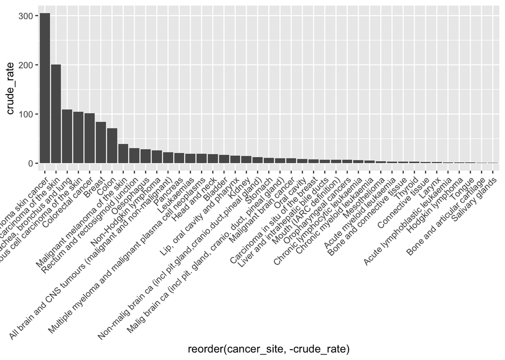

```r
cancer_incidence_data %>%
  filter(hb_name == "NHS Borders") %>%
  filter(cancer_site != "All cancer types") %>%
  filter(year == 2018) %>%
  filter(sex == "All") %>%
  select(cancer_site, crude_rate) %>%
  ggplot() +
  aes(x = reorder(cancer_site, -crude_rate), y = crude_rate) +
  geom_col() +
  #theme_minimal() +
  scale_y_continuous(labels = scales::comma) +
  theme(axis.text.x = element_text(angle=45,hjust=1))
```